# Principal Component Analysis

Worked example 7.4

# 1 Simple PCA with two variables

To explain what PCA is, we can consider two variables from the regional low flow analysis: ALPHA and Q95/Q50 (Table 5.1, Figure 5.16). The values for the 21 sites are replotted in Fig. 7.17a after they have been standardized to have zero mean and unit standard deviation (now referred to as ALPHA* and Q95/Q50*).

Because ALPHA* and Q95/Q50* are correlated, PC1 captures variability along a nearly 1:1 line (Fig. 7.17a) that measures the value of this artificial variable. This new axis is PC1. PC2, is set at a 90 degree angle (orthogonal), to capture the remaining variability.

This oversimplified example allows us to visualize these underlying axes, but as we consider more variables, and therefore higher dimensions, it is more appropriate to use the loading plot (Figure 7.17b). After rotating the data into the page so that positive PC1 is along the x-axis, we see that most variance falls along this horizontal axis. In fact, if we only consider PC1, ignoring the vertical PC2, we could still reconstruct 72.14% of the ALPHA* and Q95/Q50* values. This is why PCA is so valuable for data reduction.

```r
### Select only two variables
indices_matrix <- indices %>%
    select(ALPHA, `Q95/Q50`) %>%
    as.matrix()
rownames(indices_matrix) <- indices$id
```

```r
### Run the PCA analysis with scaling
regional_pca <- prcomp(indices_matrix, scale = TRUE)

# Mean (center) and standard deviation (scale) from normalization
#regional_pca$center
#regional_pca$scale

### View the PC Loading matrix
head(regional_pca$rotation)
```

```
##                PC1        PC2
## ALPHA    0.7071068 -0.7071068
## Q95/Q50 -0.7071068 -0.7071068
```

```r
### View the PC Scores
head(regional_pca$x)
```

```
##               PC1        PC2
## 210039 -0.1404138  0.9569836
## 210054  0.5984752 -0.7416445
## 210062  0.6078436 -0.1317603
## 210088  0.1721435 -0.1278319
## 210211 -1.2826950 -0.2886183
## 210237 -0.2715253 -0.3175126
```

```r
#By default, eigenvectors in R point in the negative direction. We can adjust this with a simple change.
regional_pca$rotation <- -regional_pca$rotation
regional_pca$x <- -regional_pca$x
```

Figure 7.17: Normalized variables with the PC axes (a) and the resultant PC Loading diagram (b) for these two variables.

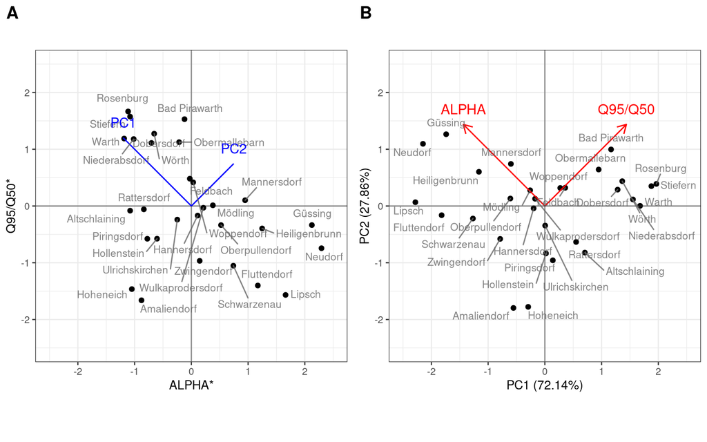

```r
### Plot the PC Loading
p2 <- autoplot(regional_pca,
        loadings.label=TRUE, loadings=TRUE,
        loadings.label.size=4, loadings.colour='red', loadings.label.vjust = -1, scale = 0) %>%
    + geom_hline(yintercept = 0, colour = "grey20", alpha = 0.5) %>%
    + geom_vline(xintercept=0, colour = "grey20", alpha = 0.5) %>%
    + geom_text_repel(vjust=-1, label=indices$station, size = 3, colour = "grey40", alpha =0.8)  %>%
    + coord_fixed(ratio=1, xlim=c(-2.5,2.5), ylim=c(-2.5,2.5))
```

# 2 PCA with all variables

If we instead consider all variables, we produce the loading plot shown in Figure 7.18a. The loading plot shows that nearly all low flow metrics load onto PC1 in the negative direction, opposite to ALPHA. Further, all of the flow metrics prior to normalization by Q50, catchment area, and ALPHA load positively onto PC2, while the normalized metrics load negatively. PC2 is highly related to watershed size, and thereby absolute flow.

```r
### Remove all the naming variables
indices_matrix <- indices %>%
    select(-id, -river, -station) %>%
#   select(ALPHA, `Q90/Q50`, `Q95/Q50`, `MAM(30)/Q50`, `MAM(10)/Q50`,`MAM(1)/Q50`) %>%
    as.matrix()
rownames(indices_matrix) <- indices$id

### Run the PCA analysis with scaling
regional_pca <- prcomp(indices_matrix, scale = TRUE)

#Adjust the sign of Eigen vectors.
regional_pca$rotation <- -regional_pca$rotation
regional_pca$x <- -regional_pca$x

### Create loading plot
p1 <- autoplot(regional_pca,
        loadings.label=TRUE, loadings=TRUE,
        loadings.label.size=3, loadings.colour='red', loadings.label.vjust = -1, scale = 0) %>%
    + geom_hline(yintercept = 0, colour = "grey20", alpha = 0.5) %>%
    + geom_vline(xintercept=0, colour = "grey20", alpha = 0.5) %>%
    #+ geom_text_repel(vjust=-1, label=indices$station, size = 3, colour = "grey40", alpha =0.8)  %>%
    + coord_fixed(ratio=1)
```

If we are interested in focusing only on the most important PCs in the analysis, there are different ways of deciding how many to include. One method is to look at the scree plot, which graphs the proportion of variance explained by each PC and only retain the components above the scree plot ‘elbow’. In Fig. 7.18b this appears at two PCs. Another common metric is to only retain components with eigen values greater than 1, which also results in retaining the first two components. These two components explain 93.2% of the total variance across 15 variables because the variables are so highly correlated (Figure 7.18a).

```r
###  Extract the PC eigen values and variance explained
pc.importance <- summary (regional_pca)

### Create scree plot data
scree_plot <- data.frame(cbind(Component=seq(1,dim(pc.importance$importance)[2]),t(pc.importance$importance)))
scree_plot$EigenVal <- scree_plot$Standard.deviation^2
scree_plot[1:5,]
```

```
##     Component Standard.deviation Proportion.of.Variance Cumulative.Proportion    EigenVal
## PC1         1          3.3005444                0.72624               0.72624 10.89359347
## PC2         2          1.7570323                0.20581               0.93205  3.08716252
## PC3         3          0.8720938                0.05070               0.98275  0.76054757
## PC4         4          0.3639048                0.00883               0.99158  0.13242668
## PC5         5          0.2496006                0.00415               0.99574  0.06230047
```

Figure 7.18: PC Loading diagram for all low flow metrics (a) and the resultant scree plot (b).

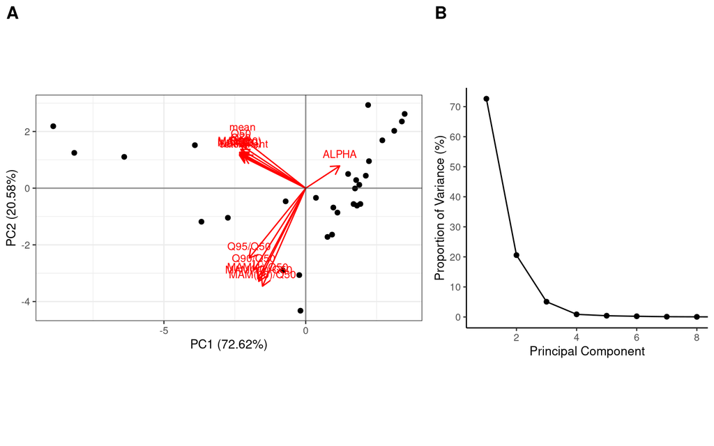

```r
### Create scree plot using proportion of variance explained
p2 <- ggplot(scree_plot, aes(Component,Proportion.of.Variance*100)) %>%
    + geom_line() %>%
    + geom_point() %>%
    + scale_x_continuous(name = "Principal Component", breaks=seq(0,30,2)) %>%
    + scale_y_continuous(name = "Proportion of Variance (%)", breaks=seq(0,100, 10)) %>%
    + theme_classic(10) %>%
    + coord_fixed(ratio = 0.1, xlim=c(0.7,8))
```